# Astronaut Database Exploration

## by Hani Jubail

## Investigation Overview

> In this presentation I would like to show the most interesting findings in the astronauts database to get an insight into the difference between male and female astronauts throughout the years and also the difference between nations in the space programs.

## Dataset Overview

> The astronauts database contains data about 1277 astronauts with 24 features like (name, original name, sex, year of birth, nationality, background (military/civilian), selection, year of selection, mission number, total number of missions, year of mission and other features. The variables are numeric and strings for the most part with some dates and categorical data like names of the missions.

## Gender Disparities in Astronomy

> The vast majority of astronauts are males with 1134 male astronauts 88.8% compared to just 143 female astronauts 11.1%.

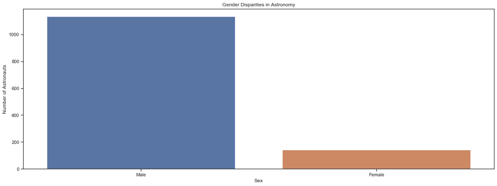

```python
plt.figure(figsize=(20,7))
sb.countplot(x="sex", y=None, data=astronauts).set(title = "Gender Disparities in Astronomy",
                                                   xlabel = "Sex",
                                                   ylabel = "Number of Astronauts");
```

## Gender Disparities in the Missions Over the Years

> The early days of astronomy female astronauts were almost not exiting for the first 2 decades, then female participation in the mission has started to rise from the mid 80's to this day.

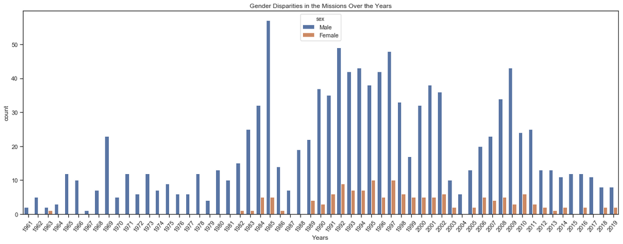

```python
plt.figure(figsize=(20,7))
plt.xticks(rotation=50);
sb.countplot(x="year_of_mission", hue="sex",
           data=astronauts).set(title = "Gender Disparities in the Missions Over the Years",
                                xlabel = "Years");
```

## The Gender Gap in the Missions Over the Years

> In this time series, we can see in recent years that female astronauts spending more time in the missions indicating that female astronauts are taking some leading positions in recent years compared to the early years of the space program.

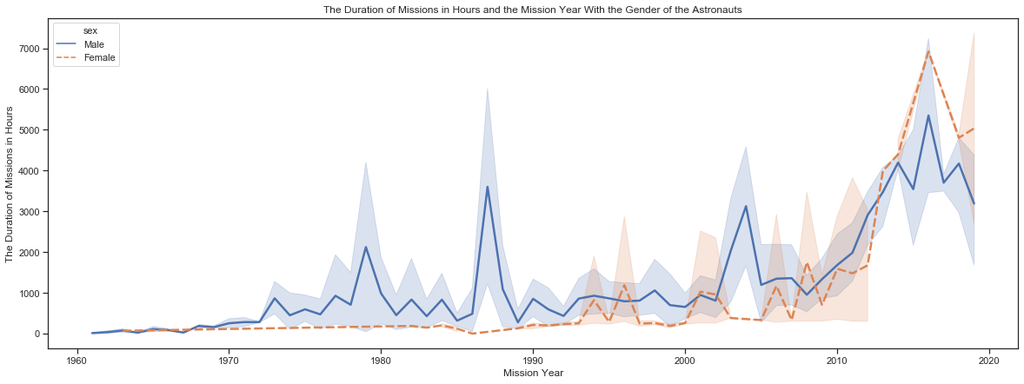

```python
plt.figure(figsize=(20,7))
sb.lineplot(x="year_of_mission", y ="hours_mission",
               hue = "sex",style="sex",linewidth=2.5,
               data=astronauts).set(title = "The Duration of Missions in Hours and the Mission Year With the Gender of the Astronauts",
                                    ylabel = "The Duration of Missions in Hours",
                                    xlabel = "Mission Year");
plt.legend(loc='upper left');
```

## The Space Race and The Nations

> From early on to the recent years the U.S. and U.S.S.R/Russia are making most missions in space, however, we can see from the plot above that Russia is spending more time than the U.S. in the missions, but other nations are starting to catch up with the U.S. and Russia and starting to make more longer missions to the space.

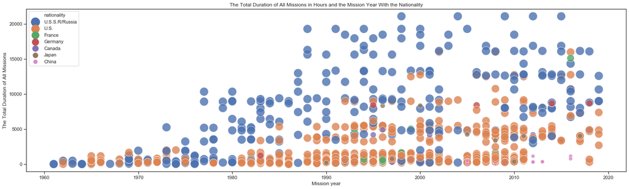

```python
top7Natslist =  astronauts["nationality"].value_counts().nlargest(7).keys().tolist()
top7Natslist
topnats = (astronauts["nationality"].isin(top7Natslist))
topnats
plt.figure(figsize=(25,7))
sb.scatterplot(x="year_of_mission", y ="total_hrs_sum",
               hue = "nationality",size="nationality",sizes=(80,400), alpha=.8,
               data=astronauts.loc[topnats]).set(title = "The Total Duration of All Missions in Hours and the Mission Year With the Nationality",
                                                 ylabel = "The Total Duration of All Missions",
                                                 xlabel = "Mission year");
```